# MOFA analysis of RNA-seq and peak histone ChIP-seq data

Ryan C. Thompson

February 21, 2018

# Preliminary Setup

First we load the necessary libraries, along with a set of utility functions.

```r
library(stringr)
library(glue)
library(forcats)
library(magrittr)
library(openxlsx)
library(SummarizedExperiment)
library(MultiAssayExperiment)
library(dplyr)
library(edgeR)
library(limma)
library(DESeq2)
library(csaw)
library(sva)
library(MOFAtools)
library(ggplot2)
library(scales)
library(GGally)
library(ggalt)
library(ggthemes)
library(ggbeeswarm)
library(splines)
library(reshape2)
library(assertthat)
library(ggfortify)
library(broom)
library(ks)
library(RColorBrewer)
library(here)

library(BSgenome.Hsapiens.UCSC.hg38)

library(doParallel)
ncores <- getOption("mc.cores", default=parallel::detectCores(logical = FALSE))
options(mc.cores=ncores)
registerDoParallel(cores=ncores)
library(BiocParallel)
register(SerialParam())
register(DoparParam())

options(future.globals.maxSize=4 * 1024^3)
library(future)
plan(multicore)

source(here("scripts/utilities.R"))

# Required in order to use DGEList objects with future
length.DGEList <- function(x) {
    length(unclass(x))
}
```

# Data loading and preprocessing

## Loading the MOFA model

First we load all the count data sets that we will be using.

```r
## TODO: Load from RDS file
mofa_path <- here("saved_data", "mofa", glue_data(params, "mofa-model_{genome}_{transcriptome}_{mofa_views}.RDS"))
mofa <- readRDS(mofa_path)
```

## Loading the TFBS overlap sets

We load the TFBS overlap data for all peaks. For RNA-seq genes, we say that a gene has a TFBS if any of its peaks overlap one.

```r
overlap_sets <- readRDS(here("saved_data", glue_data(params, "peak-tfbs-overlap_{genome}.RDS")))
promoter_overlap_sets <- readRDS(here("saved_data", glue_data(params, "promoter-tfbs-overlap_{genome}_{transcriptome}.RDS")))
overlap_sets$RNA <- bplapply(names(promoter_overlap_sets[[1]]), function(tf) {
    lapply(overlap_sets, . %>% .[[tf]] %>% str_replace("-P[0-9]+$", "")) %>%
        unlist %>% sort %>% unique
}) %>% set_names(names(overlap_sets[[1]]))
```

## Filtering TFBS overlap sets

We must discard any mention of peaks or genes that are not included in the mofa object.

```r
overlap_matrices <- lapply(names(overlap_sets), function(view) {
    mofa_features <- rownames(experiments(mofa@InputData)[[view]])
    lapply(overlap_sets[[view]], `%in%`, x=mofa_features) %>%
        do.call(what=rbind) %>% add(0) %>%
        set_colnames(mofa_features)
}) %>% setNames(names(overlap_sets))
```

# Analysis

## Basic MOFA model QC

We start by plotting the fraction of variance explained by each factor in each view.

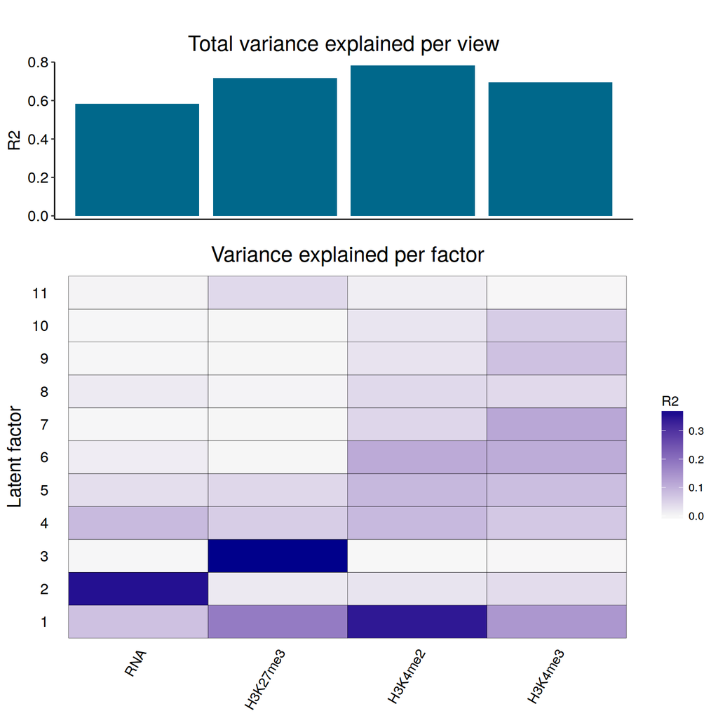

```r
plotVarianceExplained(mofa)
```

The plot shows that factors 1, 4, and 5 are shared across all 4 views, while all the others are specific to just 1 or 2 views. H3K4me2 and H3K4me3 in particular seem to share a lot of the same variation, which is expected since there is substantial overlap between their binding sites, and they are highly correlated in general.

Next, we plot the values of each latent factor for each sample, distinguishing time point and cell type by color and shape of the points, so we can see which factors correlate with the experimental effects of interest.

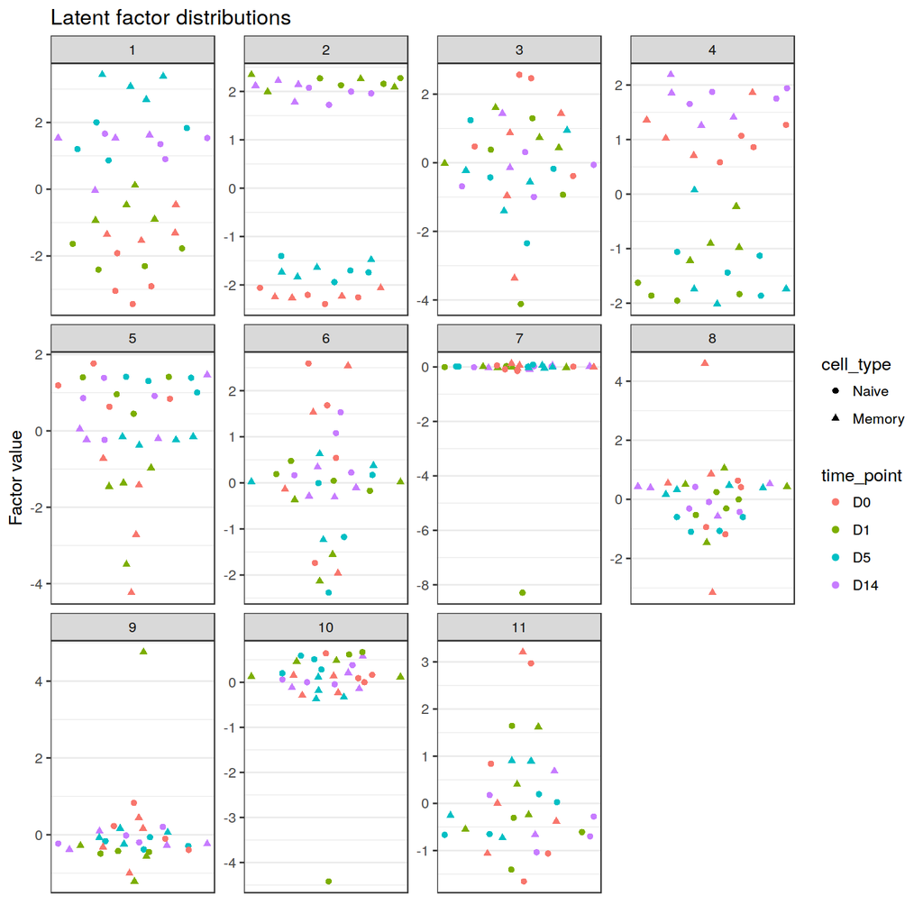

```r
factor_table <- getFactors(mofa, as.data.frame = TRUE, include_intercept = FALSE)  %>%
    mutate(sample=as.character(sample)) %>%
    inner_join(as.data.frame(colData(mofa@InputData)), by=c(sample="PrimarySample")) %>%
    arrange(cell_type, days_after_activation) %>%
    mutate(time_point = fct_inorder(time_point))
p <- ggplot(factor_table) +
    facet_wrap(~factor, scales="free") +
    aes(x=0, y=value, color=time_point, shape=cell_type) +
    geom_quasirandom() +
    scale_x_continuous(breaks=NULL) +
    labs(title="Latent factor distributions",
         x = "", y = "Factor value") +
    theme_bw()
ggprint(p)
```

This plot shows that factors 1 and 4 are associated with time point, while factor 5 is clearly associated with cell type. Other factors have weaker associations, but these are the main factors of interest. Factor 2 is clearly the RNA batch effect.

Based on the above, we identify factors 1, 4, and 5 as the most biologically interesting factors. Happily, these are the same factors that explain a non-zero fraction of variance in every view. To further characterize these factors, we plot them against each other, resulting in a series of PCA-like plots.

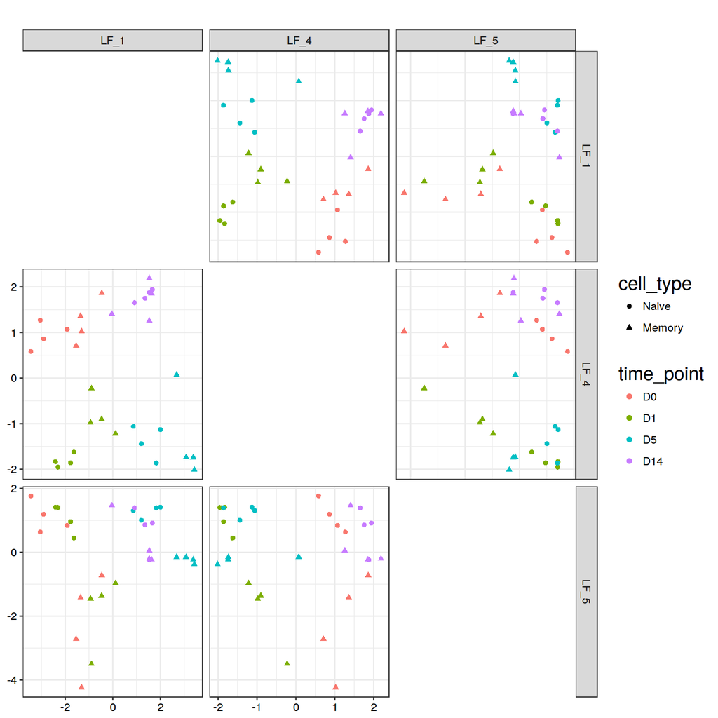

```r
factors_of_interest <- c(1,4,5)
plotFactorScatters(mofa, factors=factors_of_interest, color_by="time_point", shape_by = "cell_type")
```

These plots closely match the sva-corrected (or ComBat-corrected) MDS plots from the individual data sets, which is a good sign, since no explicit batch correction has been performed on this data.

## Feature set enrichment analysis for TFBS overlaps

```r
# fsea_results <- lapply(names(overlap_sets) %>% setdiff(c("H3K4me2", "H3K4me3")) %>% set_names, function(view) {
#     message("")
#     message(glue("Testing {view} for feature set enrichment"))
#     FeatureSetEnrichmentAnalysis(mofa, view, overlap_matrices[[view]])
# })
```

```r
# sigCounts <- lapply(names(fsea_results), function(view) {
#     fsea_results[[view]] %$%
#         tibble(Test = "Enrichment",
#                View = view,
#                Factor = colnames(pval.adj),
#                SigSets = colSums(pval.adj <= 0.05))
# }) %>% do.call(what=rbind) %>%
#     mutate_if(is.character, fct_inorder)
# p <- ggplot(sigCounts) +
#     aes(x=Factor, y=SigSets) +
#     geom_bar(stat="identity") +
#     facet_wrap(~View)
# ggprint(p)
```

## Batch correction of RNA-seq data

The RNA-seq data in this data set is known to have a severe batch effect that is confounded with the time points, making standard batch subtraction problematic. We can attempt to do better by subtracting out the predicted effect of latent factor 2, which corresponds to this batch effect.

```r
rnaseq_data <- list(None=getTrainData(mofa)$RNA)
sample.table <- colData(mofa@InputData)
sample.table$rna_batch <- getFactors(mofa, "2") %>% as.vector %>% is_less_than(0) %>% ifelse(., "A", "B")
design.NoTime <- model.matrix(~ cell_type + donor_id, sample.table)

rnaseq_data$BatchSubtract <- removeBatchEffect(rnaseq_data$None, batch=sample.table$rna_batch, design=design.NoTime)
rnaseq_data$ComBat <- ComBat(rnaseq_data$None, batch=sample.table$rna_batch, mod=design.NoTime, par.prior=TRUE)
```

```
Found2batches
```

```
Adjusting for4covariate(s) or covariate level(s)
```

```
Standardizing Data across genes
```

```
Fitting L/S model and finding priors
```

```
Finding parametric adjustments
```

```
Adjusting the Data
```

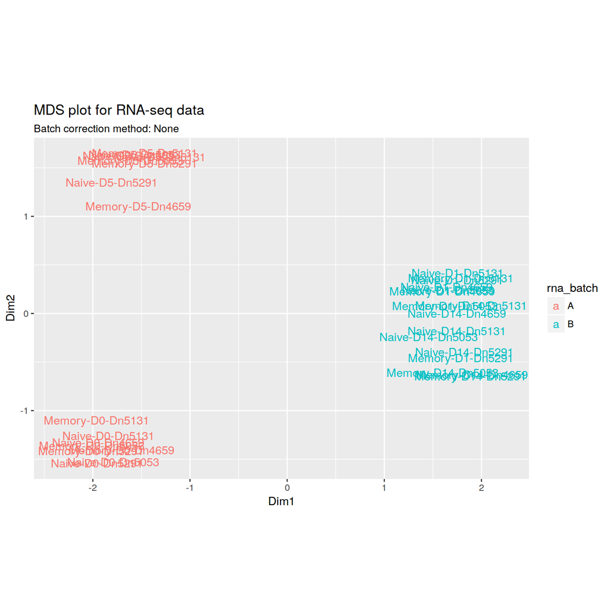

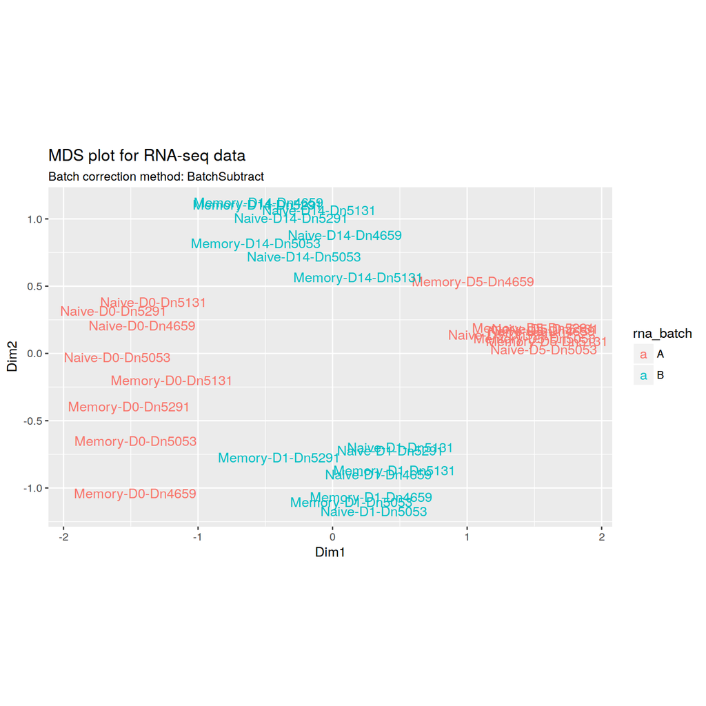

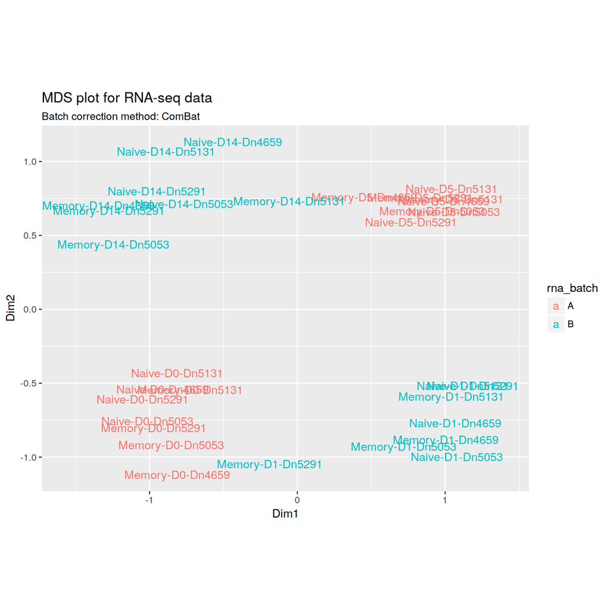

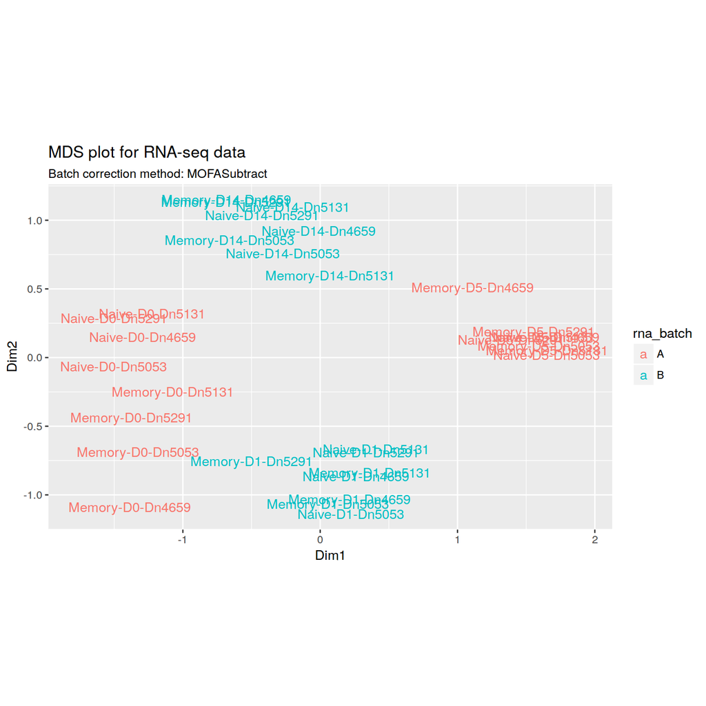

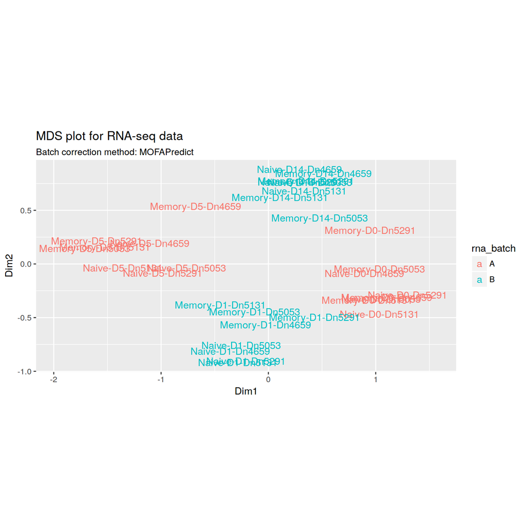

```r
rnaseq_data$MOFASubtract <- rnaseq_data$None - predict(mofa, views="RNA", factors="2")$RNA
rnaseq_data$MOFAPredict <- predict(mofa, view="RNA", factors=factors_of_interest)$RNA

doMDS <- function(x, k) {
    dmat <- suppressPlot(plotMDS(x, top=5000)$distance.matrix) %>% as.dist
    if (missing(k)) {
        k <- attr(dmat, "Size") - 1
    }
    mds <- cmdscale(dmat, k=k, eig=TRUE)
    mds$points %>% add.numbered.colnames("Dim") %>% cbind(sample.table, .)
}
mds <- lapply(rnaseq_data, doMDS, k=10)

ggmdsbatch <- function(dat, dims=1:2) {
    if (length(dims) == 1) {
        dims <- dims + c(0,1)
    }
    assert_that(length(dims) == 2)
    ggplot(as.data.frame(dat)) +
        aes_string(x=str_c("Dim", dims[1]), y=str_c("Dim", dims[2])) +
        aes(color=rna_batch, label=PrimarySample) +
        geom_text() +
        scale_x_continuous(expand=c(0.15, 0)) +
        coord_equal()
}

p <- list()
for (i in names(mds)) {
    p[[i]] <- ggmdsbatch(mds[[i]]) +
        ggtitle("MDS plot for RNA-seq data",
                subtitle = glue("Batch correction method: {i}"))
}
ggprint(p)
```